# NBC, KNN, SVM, and Ensemble Learning

#### Reading the training data from csv file

```r
library(tidyverse)
disease_train <- read_csv("Disease Prediction Training.csv", col_types = cols())
attr(disease_train, 'spec') <- NULL
```

#### Size of the training dataset

```r
dim(disease_train)
```

```
## [1] 49000    12
```

```r
str(disease_train)
```

```
## Classes 'spec_tbl_df', 'tbl_df', 'tbl' and 'data.frame': 49000 obs. of  12 variables:
##  $ Age                : num  59 64 41 50 39 54 48 51 42 41 ...
##  $ Gender             : chr  "female" "female" "female" "male" ...
##  $ Height             : num  167 150 166 172 162 163 159 171 161 159 ...
##  $ Weight             : num  88 71 83 110 61 61 89 71 72 43 ...
##  $ High Blood Pressure: num  130 140 100 130 110 120 150 110 150 90 ...
##  $ Low Blood Pressure : num  68 100 70 80 80 80 90 70 90 60 ...
##  $ Cholesterol        : chr  "normal" "normal" "normal" "normal" ...
##  $ Glucose            : chr  "normal" "normal" "normal" "normal" ...
##  $ Smoke              : num  0 0 0 1 0 0 0 0 0 0 ...
##  $ Alcohol            : num  0 0 1 0 0 0 0 0 0 0 ...
##  $ Exercise           : num  1 0 1 1 1 1 1 1 1 1 ...
##  $ Disease            : num  0 1 0 0 0 0 1 0 1 0 ...
```

## Section 1: Data preparation

#### Data quality issues

##### Missing values

```r
sum(!complete.cases(disease_train))
```

```
## [1] 0
```

There are no missing values in the dataset.

##### Data outliers

Data outliers can be determined by generating a boxpot for the desired attribute.

###### Boxplot for High Blood Pressure

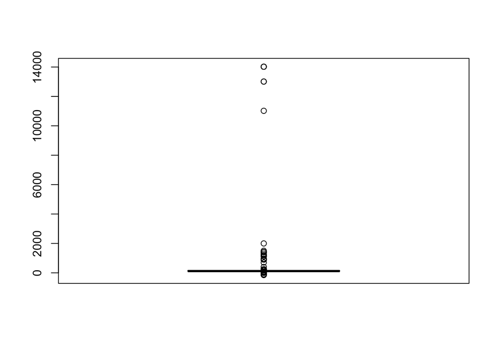

```r
boxplot(disease_train$`High Blood Pressure`)
```

As we can see there are extreme outliers in the high blood pressure values. These outliers can be replaced by the median value.

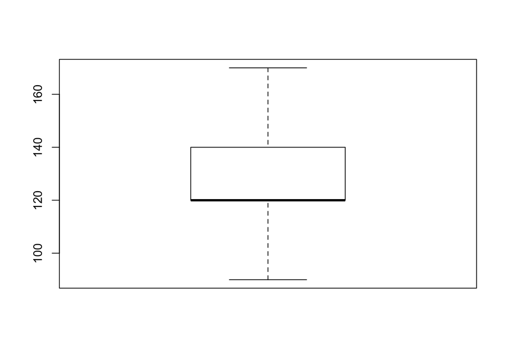

```r
disease_train$`High Blood Pressure`[disease_train$`High Blood Pressure` %in% boxplot.stats(disease_train$`High Blood Pressure`)$out] <- median(disease_train$`High Blood Pressure`, na.rm = T)
boxplot(disease_train$`High Blood Pressure`)
```

The above boxplot shows distribution of high blood pressure after removing outliers.

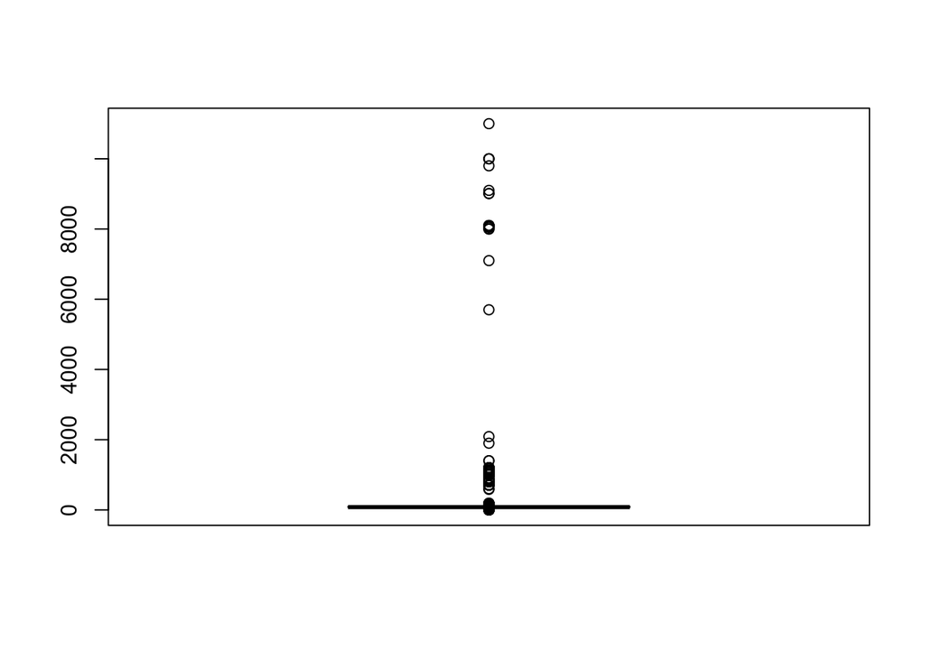

```r
boxplot(disease_train$`Low Blood Pressure`)
```

Similar to high blood pressure, the extreme outliers in low blood pressure are also replaced by the corresponding median values.

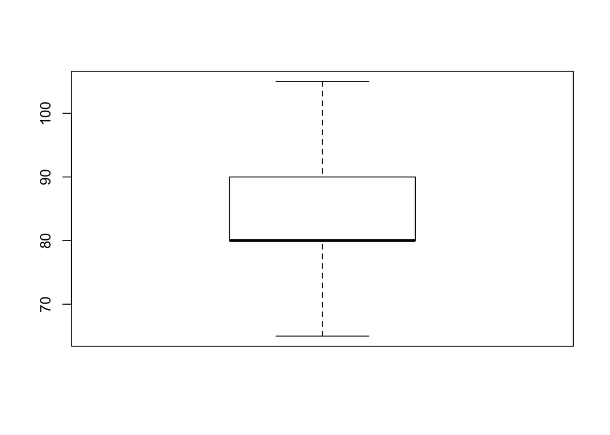

```r
disease_train$`Low Blood Pressure`[disease_train$`Low Blood Pressure` %in% boxplot.stats(disease_train$`Low Blood Pressure`)$out] <- median(disease_train$`Low Blood Pressure`, na.rm = T)
boxplot(disease_train$`Low Blood Pressure`)
```

The above boxplot shows distribution of low blood pressure after removing outliers.

#### Numerization

The machine learning algorithms to be implemented work well with numerical data. So we create dummy variables for categorical values using onehot encoding. Also converting the target variable to factors.

```r
library(onehot)
encoder <- onehot(disease_train, stringsAsFactors = TRUE, max_levels = 20)
train_1 <- data.frame(predict(encoder, disease_train))
disease_train$Disease <- as.factor(disease_train$Disease)
train_1$Disease <- as.factor(train_1$Disease)
```

#### Data normalization and standardization

Distance based machine learning algorithms require the data to be scaled in order to bring all th features to the same level. Hence, we scale all the numeric features in the datase provided.

```r
train_2 <- train_1
train_2$Age <- scale(train_1$Age, center = TRUE, scale = TRUE)
train_2$Height <- scale(train_1$Height, center = TRUE, scale = TRUE)
train_2$Weight <- scale(train_1$Weight, center = TRUE, scale = TRUE)
train_2$High.Blood.Pressure <- scale(train_1$High.Blood.Pressure, center = TRUE, scale = TRUE)
train_2$Low.Blood.Pressure <- scale(train_1$Low.Blood.Pressure, center = TRUE, scale = TRUE)
```

#### Train and validation datasets

Since we require validation dataset to determine the accuracy of the model, we split the train dataset into train and validation data. Test data: 80% Validation data: 20%

```r
library(caret)
set.seed(188)
train_index <- createDataPartition(train_1$Disease, p = 0.8, list = FALSE)
strain1 <- train_1[train_index, ]
sval1 <- train_1[-train_index, ]

train_index <- createDataPartition(train_2$Disease, p = 0.8, list = FALSE)
strain2 <- train_2[train_index, ]
sval2 <- train_2[-train_index, ]
```

#### Exploratory data analysis

##### How many patients have cardiac disease?

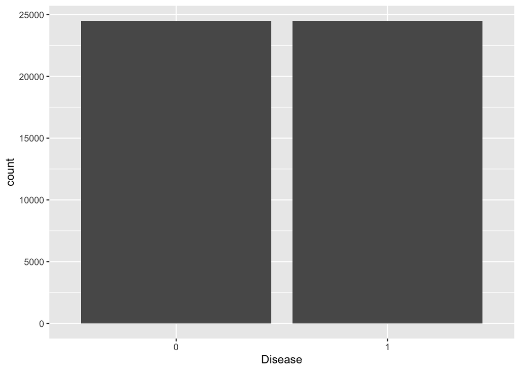

```r
library(ggplot2)
ggplot(disease_train) +
  geom_bar(aes(x = Disease))
```

The train dataset has equal nuber of people who have and don’t have disease.

##### How many patients who smoke have disease?

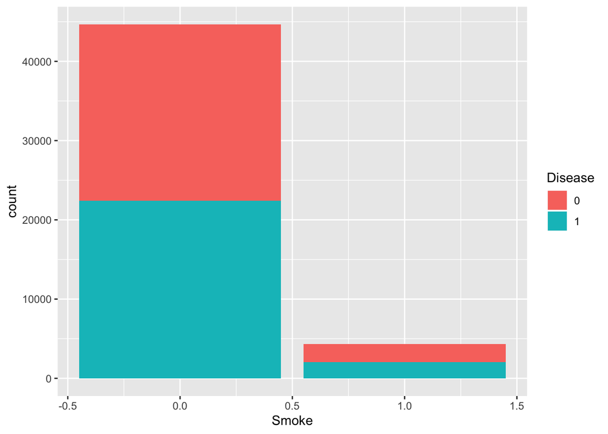

```r
ggplot(disease_train) +
  geom_bar(aes(x = Smoke, fill = Disease))
```

##### How many patients who drink have disease?

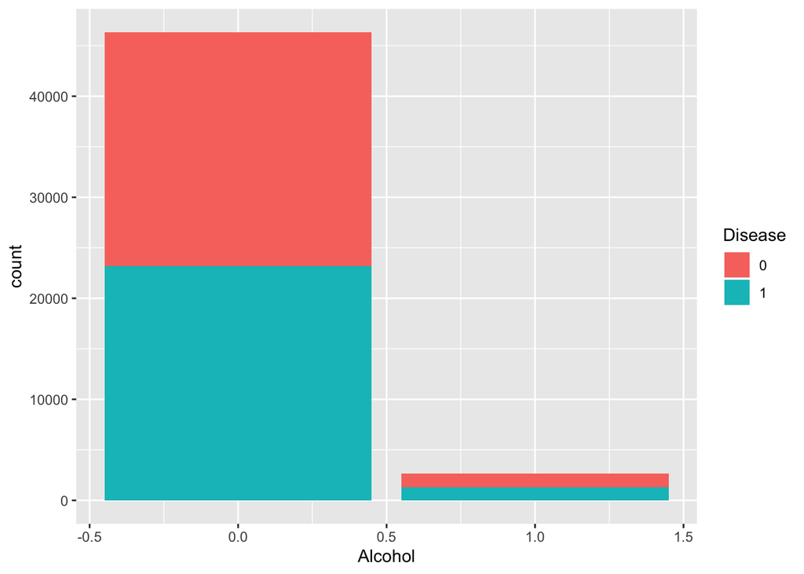

```r
ggplot(disease_train) +
  geom_bar(aes(x = Alcohol, fill = Disease))
```

##### How many patients who exercise regularly have disease?

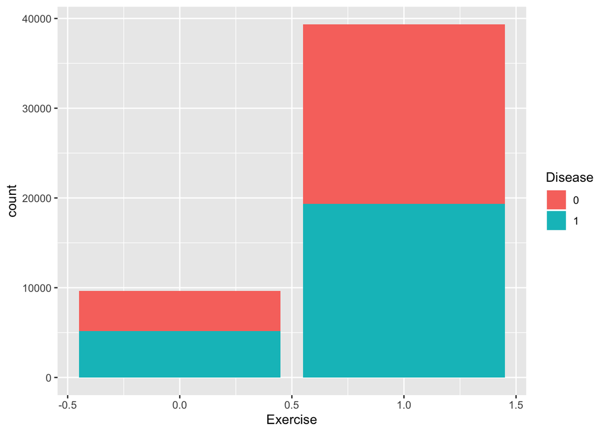

```r
ggplot(disease_train) +
  geom_bar(aes(x = Exercise, fill = Disease))
```

##### What proportion of male and female patients have cardiac disease?

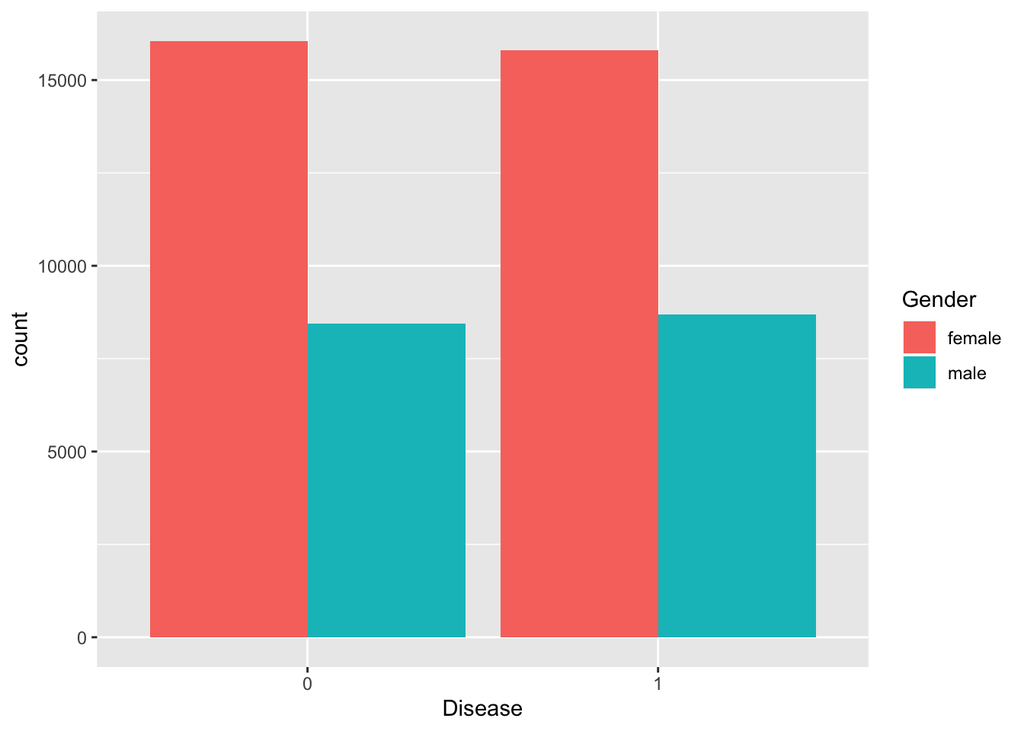

```r
ggplot(disease_train, aes(x = Disease, fill = Gender)) +
  geom_bar(position = "dodge")
```

## Section 2: Build, tune and evaluate various machine learning algorithms

#### Naive Bayes Classifier

The Naive Bayes Classifier is trained using 3 fold cross validation for resampling and tuning the values of fl between 1 and 3, userkernel as TRUE or FALSE.

```r
model_nb <- train(Disease ~ ., data = strain1, method = "nb",
             trControl = trainControl(method = "cv", number = 3),
             tuneGrid = expand.grid(fL = 1:3, usekernel = c(TRUE, FALSE), adjust = 1:3))
model_nb
```

```
## Naive Bayes
##
## 39201 samples
##    16 predictor
##     2 classes: '0', '1'
##
## No pre-processing
## Resampling: Cross-Validated (3 fold)
## Summary of sample sizes: 26134, 26134, 26134
## Resampling results across tuning parameters:
##
##   fL  usekernel  adjust  Accuracy   Kappa
##   1   FALSE      1       0.6765644  0.3531189
##   1   FALSE      2       0.6765644  0.3531189
##   1   FALSE      3       0.6765644  0.3531189
##   1    TRUE      1       0.6325859  0.2651393
##   1    TRUE      2       0.6381215  0.2762120
##   1    TRUE      3       0.6533252  0.3066232
##   2   FALSE      1       0.6765644  0.3531189
##   2   FALSE      2       0.6765644  0.3531189
##   2   FALSE      3       0.6765644  0.3531189
##   2    TRUE      1       0.6325859  0.2651393
##   2    TRUE      2       0.6381215  0.2762120
##   2    TRUE      3       0.6533252  0.3066232
##   3   FALSE      1       0.6765644  0.3531189
##   3   FALSE      2       0.6765644  0.3531189
##   3   FALSE      3       0.6765644  0.3531189
##   3    TRUE      1       0.6325859  0.2651393
##   3    TRUE      2       0.6381215  0.2762120
##   3    TRUE      3       0.6533252  0.3066232
##
## Accuracy was used to select the optimal model using the largest value.
## The final values used for the model were fL = 1, usekernel = FALSE and adjust
##  = 1.
```

The final model generated has fL = 1 for zero probability issue and considers a normal density function.

##### Performance evaluation of NBC

Performance of the model can be determined by obtaining the confusion matrix for the validation dataset.

```r
predict_nb <- predict(model_nb, newdata = sval1, type = "raw")
confusionMatrix(predict_nb, sval1$Disease)
```

```
## Confusion Matrix and Statistics
##
##           Reference
## Prediction    0    1
##          0 3849 2016
##          1 1051 2883
##
##                Accuracy : 0.687
##                  95% CI : (0.6777, 0.6962)
##     No Information Rate : 0.5001
##     P-Value [Acc > NIR] : < 2.2e-16
##
##                   Kappa : 0.374
##
##  Mcnemar's Test P-Value : < 2.2e-16
##
##             Sensitivity : 0.7855
##             Specificity : 0.5885
##          Pos Pred Value : 0.6563
##          Neg Pred Value : 0.7328
##              Prevalence : 0.5001
##          Detection Rate : 0.3928
##    Detection Prevalence : 0.5985
##       Balanced Accuracy : 0.6870
##
##        'Positive' Class : 0
##
```

- The classifier built has an accuracy of 68.7%.
- It correctly predicts 78% of positive cases and 58% percent of negative cases.

#### K-Nearest Neighbors

The KNN model is built for number of neighbors ranging between 1 to 10.

```r
model_knn <- train(Disease ~ ., data = strain2, method = "knn",
                    tuneGrid = data.frame(k = seq(1, 10)),
                    trControl = trainControl(method = "repeatedcv",
                                             number = 5, repeats = 3))
model_knn
```

```
## k-Nearest Neighbors
##
## 39201 samples
##    16 predictor
##     2 classes: '0', '1'
##
## No pre-processing
## Resampling: Cross-Validated (5 fold, repeated 3 times)
## Summary of sample sizes: 31362, 31361, 31360, 31361, 31360, 31362, ...
## Resampling results across tuning parameters:
##
##   k   Accuracy   Kappa
##    1  0.6423814  0.2847627
##    2  0.6419478  0.2838952
##    3  0.6782053  0.3564101
##    4  0.6791831  0.3583656
##    5  0.6946504  0.3893000
##    6  0.6956452  0.3912894
##    7  0.7040210  0.4080409
##    8  0.7035873  0.4071734
##    9  0.7098797  0.4197580
##   10  0.7094460  0.4188904
##
## Accuracy was used to select the optimal model using the largest value.
## The final value used for the model was k = 9.
```

The model has 9 nearest neighbors.

##### Performance evaluation of KNN

Obtaining confusion matrix for validation data to evaluate performance.

```r
predict_knn <- predict(model_knn, newdata = sval2)
confusionMatrix(predict_knn, sval2$Disease)
```

```
## Confusion Matrix and Statistics
##
##           Reference
## Prediction    0    1
##          0 3545 1486
##          1 1355 3413
##
##                Accuracy : 0.7101
##                  95% CI : (0.701, 0.719)
##     No Information Rate : 0.5001
##     P-Value [Acc > NIR] : < 2e-16
##
##                   Kappa : 0.4201
##
##  Mcnemar's Test P-Value : 0.01473
##
##             Sensitivity : 0.7235
##             Specificity : 0.6967
##          Pos Pred Value : 0.7046
##          Neg Pred Value : 0.7158
##              Prevalence : 0.5001
##          Detection Rate : 0.3618
##    Detection Prevalence : 0.5134
##       Balanced Accuracy : 0.7101
##
##        'Positive' Class : 0
##
```

- The model has an accuracy of 71%.
- It has a probability of 0.72 of correctly predicting positive cases and a probability of 0.69 of correctly predicting negative cases.

#### Random Forest

```r
model_rf <- train(Disease ~ ., data = strain2, method = "rf",
                   trGrid = expand.grid(.mtry = c(2, 5, 9, 15)),
                   trControl = trainControl(method = "cv", number = 3))
model_rf
```

```
## Random Forest
##
## 39201 samples
##    16 predictor
##     2 classes: '0', '1'
##
## No pre-processing
## Resampling: Cross-Validated (3 fold)
## Summary of sample sizes: 26134, 26134, 26134
## Resampling results across tuning parameters:
##
##   mtry  Accuracy   Kappa
##    2    0.7281957  0.4563862
##    9    0.7031963  0.4063930
##   16    0.6985026  0.3970057
##
## Accuracy was used to select the optimal model using the largest value.
## The final value used for the model was mtry = 2.
```

The final model has 2 variables available for splitting at each tree node.

##### Performance evaluation of RF

Confusion matrix is used to determine the performance of the model.

```r
predict_rf <- predict(model_rf, newdata = sval2)
confusionMatrix(predict_rf, sval2$Disease)
```

```
## Confusion Matrix and Statistics
##
##           Reference
## Prediction    0    1
##          0 3864 1591
##          1 1036 3308
##
##                Accuracy : 0.7319
##                  95% CI : (0.723, 0.7407)
##     No Information Rate : 0.5001
##     P-Value [Acc > NIR] : < 2.2e-16
##
##                   Kappa : 0.4638
##
##  Mcnemar's Test P-Value : < 2.2e-16
##
##             Sensitivity : 0.7886
##             Specificity : 0.6752
##          Pos Pred Value : 0.7083
##          Neg Pred Value : 0.7615
##              Prevalence : 0.5001
##          Detection Rate : 0.3943
##    Detection Prevalence : 0.5567
##       Balanced Accuracy : 0.7319
##
##        'Positive' Class : 0
##
```

- The model has an accuracy of 73.1%.
- It has a sensitivity of 0.78 and specificity of 0.67.

#### Gradient Boost Machine

The GBM model is trained with 3 repeated 5 fold cross validation.

```r
model_gbm <- train(Disease ~ ., data = strain2, method = "gbm",
                   trControl = trainControl(method = "repeatedcv",
                                            number = 5, repeats = 3))
```

```r
model_gbm
```

```
## Stochastic Gradient Boosting
##
## 39201 samples
##    16 predictor
##     2 classes: '0', '1'
##
## No pre-processing
## Resampling: Cross-Validated (5 fold, repeated 3 times)
## Summary of sample sizes: 31361, 31361, 31360, 31362, 31360, 31361, ...
## Resampling results across tuning parameters:
##
##   interaction.depth  n.trees  Accuracy   Kappa
##   1                   50      0.7171671  0.4343266
##   1                  100      0.7228812  0.4457561
##   1                  150      0.7254407  0.4508758
##   2                   50      0.7250835  0.4501626
##   2                  100      0.7297518  0.4594999
##   2                  150      0.7310868  0.4621702
##   3                   50      0.7283658  0.4567284
##   3                  100      0.7309762  0.4619496
##   3                  150      0.7316650  0.4633274
##
## Tuning parameter 'shrinkage' was held constant at a value of 0.1
##
## Tuning parameter 'n.minobsinnode' was held constant at a value of 10
## Accuracy was used to select the optimal model using the largest value.
## The final values used for the model were n.trees = 150, interaction.depth =
##  3, shrinkage = 0.1 and n.minobsinnode = 10.
```

The final model has 150 tress with interaction depth of 3 and 0.1 shrinkage.

##### Performance evaluation of GBM

A confusion matrix for the validation data is created for evaluating the performance of the model.

```r
predict_gbm <- predict(model_gbm, newdata = sval2)
confusionMatrix(predict_gbm, sval2$Disease)
```

```
## Confusion Matrix and Statistics
##
##           Reference
## Prediction    0    1
##          0 3757 1452
##          1 1143 3447
##
##                Accuracy : 0.7352
##                  95% CI : (0.7263, 0.7439)
##     No Information Rate : 0.5001
##     P-Value [Acc > NIR] : < 2.2e-16
##
##                   Kappa : 0.4704
##
##  Mcnemar's Test P-Value : 1.483e-09
##
##             Sensitivity : 0.7667
##             Specificity : 0.7036
##          Pos Pred Value : 0.7213
##          Neg Pred Value : 0.7510
##              Prevalence : 0.5001
##          Detection Rate : 0.3834
##    Detection Prevalence : 0.5316
##       Balanced Accuracy : 0.7352
##
##        'Positive' Class : 0
##
```

- GBM has an accuracy of 73.5%.
- It has good sensitivity and specificity of 0.76 and 0.70 respectively.

#### Support Vector Machine

##### Linear SVM

Linear SCM is trained with 5 fold bootstrap for for penalty cost C ranging between 0, 1 0.05.

```r
model_svm_linear <- train(Disease ~ ., data = strain2, method = "svmLinear",
                          trControl = trainControl(method = "boot", number = 5),
                          tuneGrid = expand.grid(C = seq(0, 1, 0.05)))
model_svm_linear
```

```
## Support Vector Machines with Linear Kernel
##
## 39201 samples
##    16 predictor
##     2 classes: '0', '1'
##
## No pre-processing
## Resampling: Bootstrapped (5 reps)
## Summary of sample sizes: 39201, 39201, 39201, 39201, 39201
## Resampling results across tuning parameters:
##
##   C     Accuracy   Kappa
##   0.00        NaN        NaN
##   0.05  0.7250784  0.4499672
##   0.10  0.7251478  0.4501060
##   0.15  0.7251205  0.4500509
##   0.20  0.7250649  0.4499396
##   0.25  0.7250510  0.4499121
##   0.30  0.7250511  0.4499120
##   0.35  0.7250649  0.4499397
##   0.40  0.7250510  0.4499119
##   0.45  0.7250788  0.4499676
##   0.50  0.7250789  0.4499676
##   0.55  0.7250927  0.4499952
##   0.60  0.7250926  0.4499948
##   0.65  0.7250649  0.4499395
##   0.70  0.7250927  0.4499950
##   0.75  0.7250648  0.4499395
##   0.80  0.7250789  0.4499676
##   0.85  0.7250648  0.4499395
##   0.90  0.7251066  0.4500229
##   0.95  0.7250371  0.4498843
##   1.00  0.7250510  0.4499117
##
## Accuracy was used to select the optimal model using the largest value.
## The final value used for the model was C = 0.1.
```

##### Performance evaluation of linear SVM

Deteriming the performance of the model using confusion matrix.

```r
predict_svm_linear <- predict(model_svm_linear, newdata = sval2)
confusionMatrix(predict_svm_linear, sval2$Disease)
```

```
## Confusion Matrix and Statistics
##
##           Reference
## Prediction    0    1
##          0 3972 1743
##          1  928 3156
##
##                Accuracy : 0.7274
##                  95% CI : (0.7185, 0.7362)
##     No Information Rate : 0.5001
##     P-Value [Acc > NIR] : < 2.2e-16
##
##                   Kappa : 0.4548
##
##  Mcnemar's Test P-Value : < 2.2e-16
##
##             Sensitivity : 0.8106
##             Specificity : 0.6442
##          Pos Pred Value : 0.6950
##          Neg Pred Value : 0.7728
##              Prevalence : 0.5001
##          Detection Rate : 0.4053
##    Detection Prevalence : 0.5832
##       Balanced Accuracy : 0.7274
##
##        'Positive' Class : 0
##
```

- The model has f=good accuracy, sensitivity and specifity.
- It has higher probability of correctly predicting if a patient has a disease or not.

##### Non-linear SVM

```r
library(kernlab)
model_svm_rbf <- ksvm(Disease ~ ., data = strain2, method = "svmRadial",
                       tuneGrid = expand.grid(sigma = seq(0, 1, 0.1),
                                              C = seq(0, 1, 0.1)),
                       trControl = trainControl(method = "cv",
                                                number = 3))
```

##### Performance evaluation of non-linear SVM

Evaluating the performance using confusion matrix

```r
predict_svm_rbf <- predict(model_svm_rbf, newdata = sval2)
confusionMatrix(predict_svm_rbf, sval2$Disease)
```

```
## Confusion Matrix and Statistics
##
##           Reference
## Prediction    0    1
##          0 3848 1539
##          1 1052 3360
##
##                Accuracy : 0.7356
##                  95% CI : (0.7267, 0.7443)
##     No Information Rate : 0.5001
##     P-Value [Acc > NIR] : < 2.2e-16
##
##                   Kappa : 0.4712
##
##  Mcnemar's Test P-Value : < 2.2e-16
##
##             Sensitivity : 0.7853
##             Specificity : 0.6859
##          Pos Pred Value : 0.7143
##          Neg Pred Value : 0.7616
##              Prevalence : 0.5001
##          Detection Rate : 0.3927
##    Detection Prevalence : 0.5497
##       Balanced Accuracy : 0.7356
##
##        'Positive' Class : 0
##
```

#### Best performing models

[output not shown]

- The most commonly used metric for performance evaluation is RMSE.
- In order to produce unbiased and low variance estimates, performance of the models can be determined by using hold out methods like creating a confusion matrix for the validation data.
- Another metric that can be used id ROC curve. The advantage is that it is independent of the change in proportion of data points.
- For classification problems Gini coefficient can be used for evaluating the models.
- Perofrmance of the above models are estimated using confusion matrix.

## Section 3: Prediction and interpretation

#### Reading the testing data from csv file

```r
disease_test <- read_csv("Disease Prediction Testing.csv", col_types = cols())
```

#### Data Outliers

Replacing data outliers in High Blood Pressure and Low Blood Pressure with the median values.

```r
disease_test$`High Blood Pressure`[disease_test$`High Blood Pressure` %in% boxplot.stats(disease_test$`High Blood Pressure`)$out] <- median(disease_test$`High Blood Pressure`, na.rm = T)
disease_test$`Low Blood Pressure`[disease_test$`Low Blood Pressure` %in% boxplot.stats(disease_test$`Low Blood Pressure`)$out] <- median(disease_test$`Low Blood Pressure`, na.rm = T)
```

#### Numerization, normalization and standardization

Since the models are trained by coneverting categorical variables to dummies and scaling hte numeric vales, it is necessary to do the same with the testing dataset inorder to get accurate predictions.

```r
encoder <- onehot(disease_test, stringsAsFactors = TRUE, max_levels = 20)
test1 <- data.frame(predict(encoder, disease_test))

test2 <- test1
test2$Age <- scale(test1$Age, center = TRUE, scale = TRUE)
test2$Height <- scale(test1$Height, center = TRUE, scale = TRUE)
test2$Weight <- scale(test1$Weight, center = TRUE, scale = TRUE)
test2$High.Blood.Pressure <- scale(test1$High.Blood.Pressure, center = TRUE, scale = TRUE)
test2$Low.Blood.Pressure <- scale(test1$Low.Blood.Pressure, center = TRUE, scale = TRUE)
```

#### Prediction using Naive Bayes Classifier

```r
nbc_pred <- predict(model_nb, newdata = test1, type = "raw")
```

#### Prediction using K-Nearest Neighbors

```r
knn_pred <- predict(model_knn, newdata = test2)
```

#### Prediction using Random Forest

```r
rf_pred <- predict(model_rf, newdata = test2)
```

#### Prediction using Gradient Boost Machine

```r
gbm_pred <- predict(model_gbm, newdata = test2)
```

#### Prediciton using linear Support Vector Machine

```r
lsvm_pred <- predict(model_svm_linear, newdata = test2)
```

#### Prediction using non-linear Suppport Vector Machine

```r
nlsvm_pred <- predict(model_svm_rbf, newdata = test2)
```

#### Combining hte predictions made by all six models

```r
prediction <- data.frame(ID = disease_test$ID)
prediction$NBC <- nbc_pred
prediction$KNN <- knn_pred
prediction$'SVM-Linear' <- lsvm_pred
prediction$'SVM-RBF' <- nlsvm_pred
prediction$RF <- rf_pred
prediction$GBM <- gbm_pred
```

#### Writing prediction results to csv file

```r
write.csv(prediction, "prediction.csv")
```